# Text-mining for species occurrences in the Proceedings of the Natural Academy of Sciences of Philadelphia

A report for the 2021 LEADING program

Amanda Whitmire, Fellow | Steven Dilliplane, Mentor

2022-03-04

## Fellowship Goal:

Develop a process to correctly identify species occurrences (species + place + date) in the text of the Proceedings of the Academy of Natural Sciences of Philadelphia (ANSP; 1841-1922)

This corpus is available at the [Biodiversity Heritage Library](https://www.biodiversitylibrary.org/bibliography/6885) (BHL)

## Why?

We are interested in how this corpus may be leveraged for historical species occurrence data so that we can help fill in the sparse occurrence data from this time period. Take a quick look at the data showing all species occurrence records from the Global Biodiversity Information Facility (GBIF), from 1800 - 2000 (pre-iNaturalist). While the scale obscures the actual number of observations prior to 1950 (it’s not zero!), you get the gist of the problem of a lack of “old data.”

https://www.gbif.org/

[figure not shown]

## How?

We don’t have it all figured out yet, but expect that this will involve *many* steps of data processing and cleaning, training a natural language processing model on this corpus (which is a *weird* corpus), exploratory data analysis and visualization, and more. If we can get it to work (and this is a big IF), we will be able to automate identifying relationships like the one shown below. This example includes habitat, but we are focused on the relations between date + place + species.

from: Nguyen N, Gabud R, Ananiadou S (2019) COPIOUS: A gold standard corpus of named entities towards extracting species occurrence from biodiversity literature. Biodiversity Data Journal 7: e29626. https://doi.org/10.3897/BDJ.7.e29626

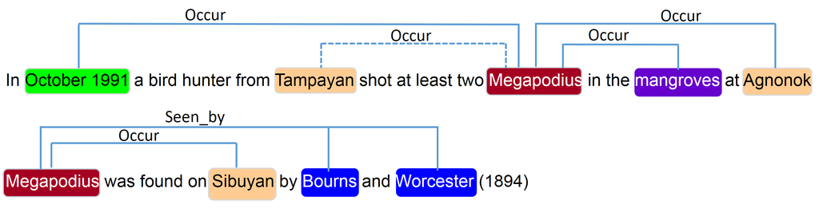

I started out by making a [detailed outline](https://docs.google.com/spreadsheets/d/1hK18L0VZuvcwatd0jhAtb-khHUu9Ki3fCrNIrwodZpU/edit?usp=sharing) of the process in Google Sheets. This is a process that I picked up from Nicole Coleman, who I am collaborating with on another Collections as Data [project](https://sul-dlss-labs.github.io/spoc/intro.html) to look for species occurrences in a time-series of student papers from Hopkins Marine Station. She came up with the general layout and columns, and I really like it.

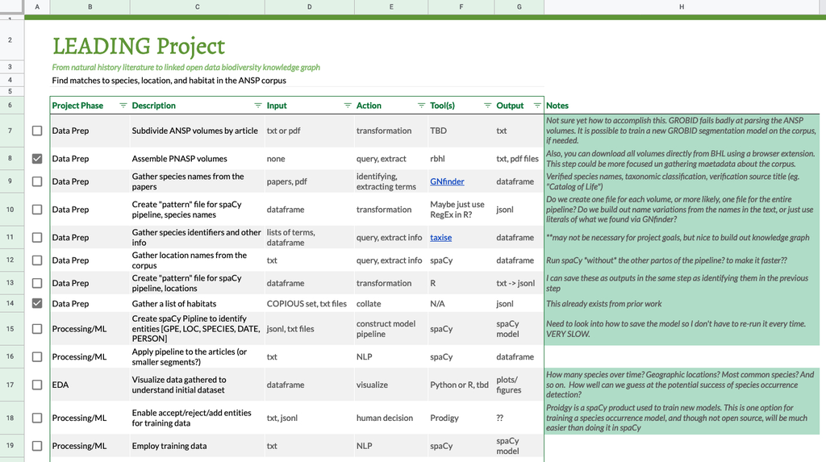

## Workflow Visualization

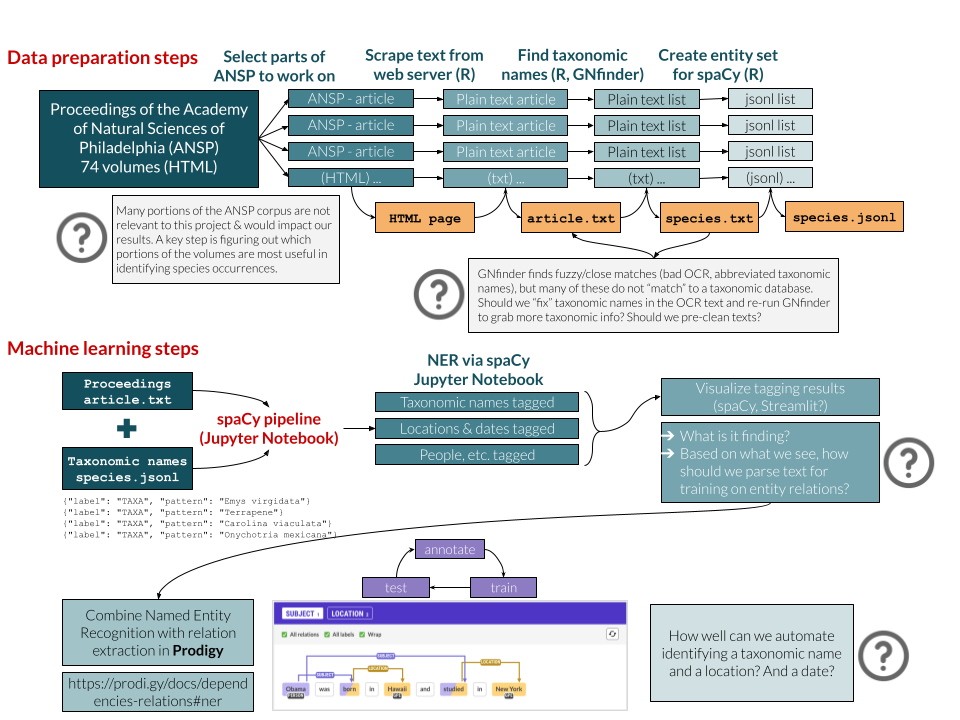